# PSTAT 131 Final Project

Sumeng Xu

2023-12-15

# Introduction

Throughout my life, the concept of grades has been omnipresent: from the early days of kindergarten, where grades were synonymous with the number of stickers I collected, to elementary school, where they represented the scores obtained on each test. Now, in college, the omnipresence of GPA reflects the significance of grades. Receiving a high grade is often a goal for most of the class, instead of actually learning the real knowledge. Student often choose a “easier” class instead of the class that they are really interested in. Sometimes when I want to choose a class, my first response is to check if the class grades hard or not. To be honest, this had lead me to miss some of the interesting class.

The effort we put in in each class often reflect the grade we receive. But when students received a low grade, it’s commonly attributed to inadequate study habits or lack of attention in class. While those factors hold some truth, there also exist other factors, both intensive or extensively, that influences academic performances.

[figure not shown]

I remember few years ago, when I was applying for college, there was a study that came out saying richer family’s kids always receive a higher GPA in high school (mostly private high schools). This is an example of how factors other than students’ own performance can influence the grade. When looking at the data set, it includes lots of external factors such as the student’s family background and education of their parents. I believe those factors serve as a important role in determining student’s grade in school.

## Inspiration and Motive

The goal of this project is to build a machine learning model to predict how different factors will influence how well students perform in school. With the best model, we can use it to predict how well students will do and thus maybe also know which influence students the most; so then we can know how to improve their grade, other than just making the students to study harder.

( I have used the help from past homework, labs, and the two classification final project example for this final project)

## Data Description

The Data can be found [here](https://www.kaggle.com/datasets/joebeachcapital/students-performance/data), which I found from Kaggle. This data set consist 32 parameters with data on 145 students. (link: https://www.kaggle.com/datasets/joebeachcapital/students-performance/data)

1- Student Age (1: 18-21, 2: 22-25, 3: above 26)

2- Sex (1: female, 2: male)

3- Graduated high-school type: (1: private, 2: state, 3: other)

4- Scholarship type: (1: None, 2: 25%, 3: 50%, 4: 75%, 5: Full)

5- Additional work: (1: Yes, 2: No)

6- Regular artistic or sports activity: (1: Yes, 2: No)

7- Do you have a partner: (1: Yes, 2: No)

8- Total salary if available (1: USD 135-200, 2: USD 201-270, 3: USD 271-340, 4: USD 341-410, 5: above 410)

9- Transportation to the university: (1: Bus, 2: Private car/taxi, 3: bicycle, 4: Other)

10- Accommodation type in Cyprus: (1: rental, 2: dormitory, 3: with family, 4: Other)

11- Mother’s education: (1: primary school, 2: secondary school, 3: high school, 4: university, 5: MSc., 6: Ph.D.)

12- Father’s education: (1: primary school, 2: secondary school, 3: high school, 4: university, 5: MSc., 6: Ph.D.)

13- Number of sisters/brothers (if available): (1: 1, 2:, 2, 3: 3, 4: 4, 5: 5 or above)

14- Parental status: (1: married, 2: divorced, 3: died - one of them or both)

15- Mother’s occupation: (1: retired, 2: housewife, 3: government officer, 4: private sector employee, 5: self-employment, 6: other)

16- Father’s occupation: (1: retired, 2: government officer, 3: private sector employee, 4: self-employment, 5: other)

17- Weekly study hours: (1: None, 2: <5 hours, 3: 6-10 hours, 4: 11-20 hours, 5: more than 20 hours)

18- Reading frequency (non-scientific books/journals): (1: None, 2: Sometimes, 3: Often)

19- Reading frequency (scientific books/journals): (1: None, 2: Sometimes, 3: Often)

20- Attendance to the seminars/conferences related to the department: (1: Yes, 2: No)

21- Impact of your projects/activities on your success: (1: positive, 2: negative, 3: neutral)

22- Attendance to classes (1: always, 2: sometimes, 3: never)

23- Preparation to midterm exams 1: (1: alone, 2: with friends, 3: not applicable)

24- Preparation to midterm exams 2: (1: closest date to the exam, 2: regularly during the semester, 3: never)

25- Taking notes in classes: (1: never, 2: sometimes, 3: always)

26- Listening in classes: (1: never, 2: sometimes, 3: always)

27- Discussion improves my interest and success in the course: (1: never, 2: sometimes, 3: always)

28- Flip-classroom: (1: not useful, 2: useful, 3: not applicable)

29- Cumulative grade point average in the last semester (/4.00): (1: <2.00, 2: 2.00-2.49, 3: 2.50-2.99, 4: 3.00-3.49, 5: above 3.49)

30- Expected Cumulative grade point average in the graduation (/4.00): (1: <2.00, 2: 2.00-2.49, 3: 2.50-2.99, 4: 3.00-3.49, 5: above 3.49)

31- Course ID

32- OUTPUT Grade (0: Fail, 1: DD, 2: DC, 3: CC, 4: CB, 5: BB, 6: BA, 7: AA)

## Project Outline

In this project, I plan to use different model to answer my question on predicting student’s performances. First I will clean the data and check if there is any missing values, then I will explore the data set in details and see if there exist any correlations between the factors. The output grade will be the response variable showing the final grades. Then five models: Logistic Regression, Elastic Fit, Linear Discriminant Analysis, KNN, and Random Forest will be used to fit the data and we will see which model have the highest accuracy. We will fit the testing data into the best model and see how well the best model truly performed on predicting student’s final GPA.

# Explore the Data

First, I will load all the packages that will be used in later predictions:

```r
library(ggplot2)
library(naniar)
library(dplyr)
library(tidymodels)
library(tidyverse)
library(ISLR)
library(kknn)
library(tune)
library(themis)
library(glmnet)
library(hardhat)
library(MASS)
library(discrim)
library(corrr)
library(corrplot)
library(ggthemes)
library(yardstick)
library(vip)
```

## Load the Data

```r
library(tidyverse)
library(tidymodels)

student_data <- read_csv(file = "DATA (1).csv")
student_data%>% head()
```

```
## # A tibble: 6 × 33
##   `STUDENT ID`   `1`   `2`   `3`   `4`   `5`   `6`   `7`   `8`   `9`  `10`  `11`
##   <chr>        <dbl> <dbl> <dbl> <dbl> <dbl> <dbl> <dbl> <dbl> <dbl> <dbl> <dbl>
## 1 STUDENT1         2     2     3     3     1     2     2     1     1     1     1
## 2 STUDENT2         2     2     3     3     1     2     2     1     1     1     2
## 3 STUDENT3         2     2     2     3     2     2     2     2     4     2     2
## 4 STUDENT4         1     1     1     3     1     2     1     2     1     2     1
## 5 STUDENT5         2     2     1     3     2     2     1     3     1     4     3
## 6 STUDENT6         2     2     2     3     2     2     2     2     1     1     3
## # ℹ 21 more variables: `12` <dbl>, `13` <dbl>, `14` <dbl>, `15` <dbl>,
## #   `16` <dbl>, `17` <dbl>, `18` <dbl>, `19` <dbl>, `20` <dbl>, `21` <dbl>,
## #   `22` <dbl>, `23` <dbl>, `24` <dbl>, `25` <dbl>, `26` <dbl>, `27` <dbl>,
## #   `28` <dbl>, `29` <dbl>, `30` <dbl>, `COURSE ID` <dbl>, GRADE <dbl>
```

## Missing values

```r
tidymodels_prefer() # avoid conflicts between packages
# the number of missing values
sum(is.na(student_data))
```

```
## [1] 0
```

Wow! there is no missing values from the data, which will save me lots of work.

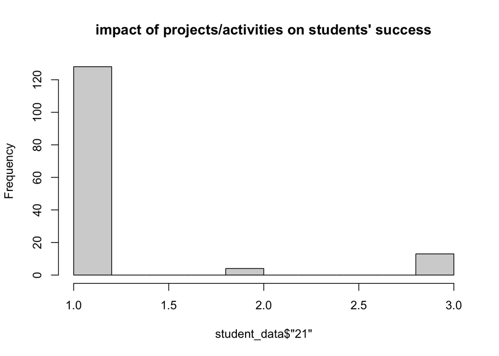

```r
hist1<- hist(student_data$'21',main= "impact of projects/activities on students' success")
```

After analyzing the histogram presented above, I decide to drop column 21, which is about the impact of the projects/activities on students’ success. The decision to drop this column is based on the understanding that its influence primarily operates outside the realm of the coursework itself. Additionally, the overwhelming observations of ‘1’, which is ‘positive’, outcomes suggests a lack of variability, potentially limiting its significance in determining the direct impact on students’ grade.

```r
drop<- c('21')
student_data1 <- student_data[ , !(names(student_data) %in% drop)]
```

For an easier way to view and understand the results, I decide to rename the names of each column to what they are correspond to:

```r
student_data1 <- student_data1 %>% rename(
  age= '1',
  sex= '2',
  hs_type= '3',
  scholarship= '4',
  additional_work = '5',
  art_sport = '6',
  partner = '7',
  salary = '8',
  transportation = '9',
  home_type= '10',
  mother_edu = '11',
  father_edu = '12',
  num_sisbro = '13',
  parental_status = '14',
  mother_job = '15',
  father_job= '16',
  weekstudy_hour = '17',
  reading_nonsci = '18',
  reading_sci = '19',
  attendance_semi = '20',
  attendance_class = '22',
  prep_midterm='23',
  prep_final = '24',
  take_note = '25',
  listen = '26',
  discussion = '27',
  flipclass= '28',
  cum_gpa_lastsem = '29',
  expcum_gpa_grad = '30'
)
```

## Visual view of the Data (EDA)

To start, I’m making a **correlation** matrix to explore the relationships between all the numeric variables:

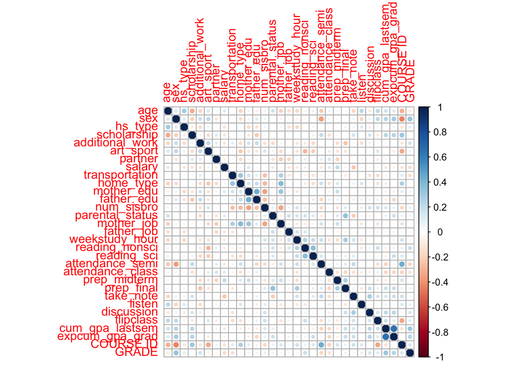

```r
student_data1 %>%
select(where(is.numeric))%>%
  cor(use='complete.obs')%>%
  corrplot()
```

It makes sense to see the variables are not correlated with each other. However if we take a closer look, there is a small square with positive correlation between the cumulative GPA of last semester and the expected GPA in graduation. This connection holds merit as a student’s performance in the preceding semester typically aligns closely with their overall GPA. It a student did well in the last semester, they are more likely to receive the same good grade in graduation. It is surprising to see that there is a somewhat positive correlation between the mother’s education level and the student’s father’s education level. Small positive correlation also exist between the `course ID` and student’s attendance to seminars/conferences related to the department, I think due to the difficulty of the course, attendance to seminars are required.

A noteworthy observation is that there is a little positive correlation between a mother’s job and transportation This unexpected finding suggests a potential connection wherein a mother’s job might influence transportation aspects. One plausible explanation could be the correlation between a mother’s work schedule and the responsibility of driving children to school, highlighting the intricate interplay between maternal occupation and the logistics of commuting to school.

To move on, I will need to convert the variables to factors in order to do classifications.

```r
student_data1 <- student_data1  %>%
  mutate( age = factor(age),
         sex = factor(sex),
         hs_type = factor(hs_type),
         scholarship = factor(scholarship),
         additional_work = factor(additional_work),
         art_sport = factor(art_sport),
         partner = factor(partner),
         salary = factor(salary),
         transportation = factor(transportation),
         home_type = factor(home_type),
         mother_edu = factor(mother_edu),
         father_edu = factor(father_edu),
         num_sisbro = factor(num_sisbro),
         parental_status = factor(parental_status),
         mother_job = factor(mother_job),
         father_job = factor(father_job),
         weekstudy_hour = factor(weekstudy_hour),
         reading_nonsci = factor(reading_nonsci),
         reading_sci = factor(reading_sci),
         attendance_semi = factor(attendance_semi),
         attendance_class = factor(attendance_class),
         prep_midterm = factor(prep_midterm),
         prep_final = factor(prep_final),
         take_note = factor(take_note),
         listen = factor(listen),
         discussion = factor(discussion),
         flipclass = factor(flipclass),
         cum_gpa_lastsem = factor(cum_gpa_lastsem),
         expcum_gpa_grad = factor(expcum_gpa_grad),
         GRADE = factor(GRADE)
         )
```

Now, I would like to see how the response variable, the final grade, is distributed among my data set:

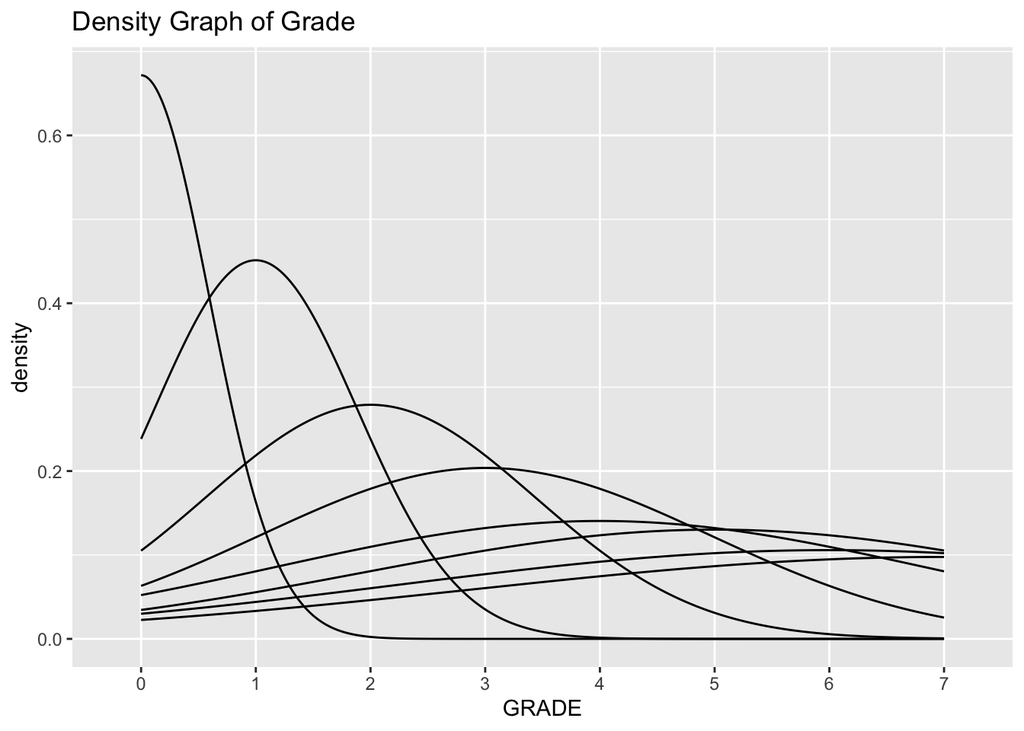

```r
student_data1 %>%
  ggplot(aes(x=GRADE))+geom_density()+labs(title = 'Density Graph of Grade')
```

Upon further examination of the dataset, I’ve noticed the presence of two distinct categories of factors: external influences such as parental information and the student’s individual performance within the class (their habits and behavior).

To evaluate their predictive efficacy, I’ve selected a few factor from each category and analyzed the proportion of each factor relative to the total count within their respective groups, using percent stacked bar chart which offers a comparative view of the contribution of these factors within their distinct groups.

First, let’s look at how sex plays the role as a predictor:

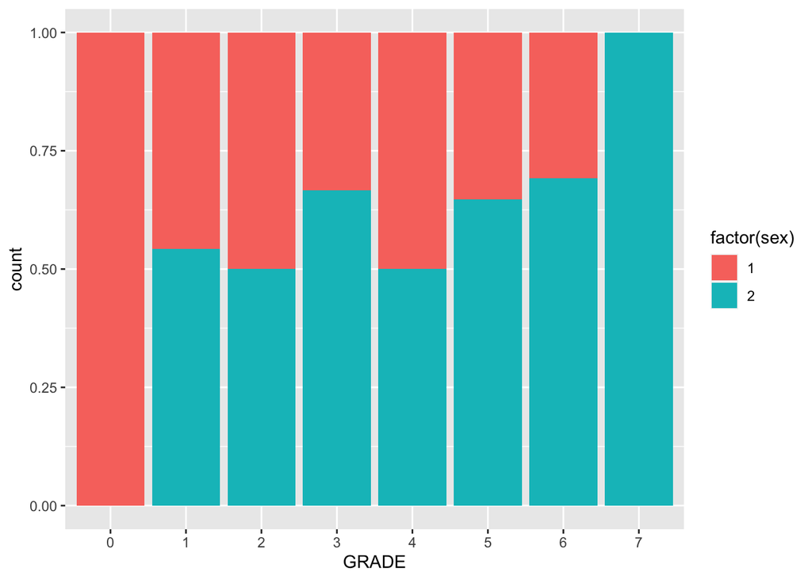

```r
student_data1%>% ggplot(aes(fill=factor(sex), x=GRADE)) +
    geom_bar(position='fill')
```

1 stands for Female and 2 stands for male. Interestingly, the lowest grade is all Female students and the highest grade is only male students. Even though the two sex are almost equally distributed among other grade 1 to 6 (DD - BA), it is still not the best predictor since it does not have all the sex in each grade.

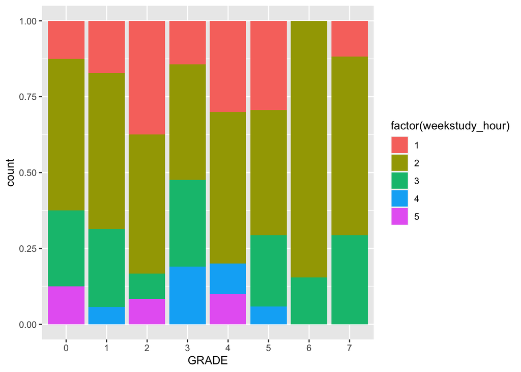

```r
student_data1%>% ggplot(aes(fill=factor(weekstudy_hour), x=GRADE)) +
    geom_bar(position='fill')
```

The time student choose to spend on study each work seems to be very spread out, but most grades have the same study hour among it. Thus I think this can be a better predictor than sex. It is not perfect because not all the factor appears in all grade distributions.

Let’s take a look at can `transportation` be a good predictor because before looking at the data set, I never though this could influence student’s performance in school.

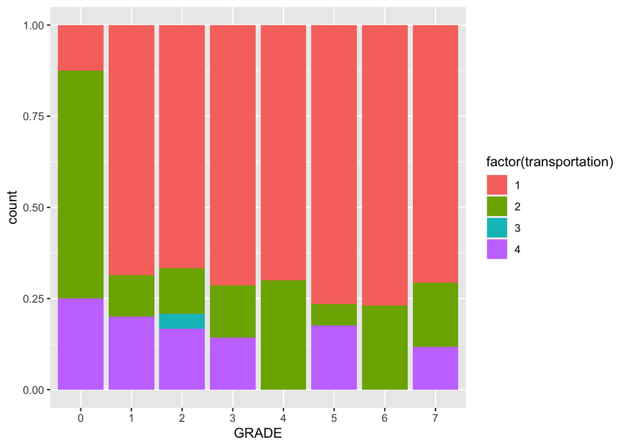

```r
student_data1%>% ggplot(aes(fill=factor(transportation), x=GRADE)) +
    geom_bar(position='fill')
```

(1: Bus, 2: Private car/taxi, 3: bicycle, 4: Other)

# Model Building

It is finally time to build our model, we will take a deeper look at how the factors are impacting the grades through various model.

## **Data Splitting**

To start, I will first split the data into training group and testing group. The data set is not large thus I decided to use 75% for the probability. I will use the training set to train the data with different models, and see the models’ performance and use the testing data to see how good the final selected model is. Doing so allowed me to minimize error and have better understandings towards the models.

```r
set.seed(2207)
student_split<- initial_split(student_data1, prop = 0.75, strata = GRADE)
student_train<- training(student_split)
student_test<- testing(student_split)
```

## K-fold cross-validation

We will use K-fold cross validation towards the response variable `OUTPUT grade` with 7 folds. The purpose for k-fold cross-validation is to use re-sampling method to evaluate predictive models. Stratified cross validation helps to improve the imbalanced data issue in the dataset. It randomly split the data into k folds, then the model is trained k times, with different fold.

```r
student_folds <- vfold_cv(student_train, v=7, strata = GRADE)
```

```r
dim(student_train)
```

```
## [1] 107  32
```

```r
dim(student_test)
```

```
## [1] 38 32
```

There are 107 observations in the training set, and 38 observations in the testing set.

## Create a recipe

Just like how it is named, a recipe, is similar to how people use a recipe in cooking. When cooking, we need a recipe with all the ingredients and steps to finish a course; It is the same in Machine learning. Here we create a recipe to choosing a machine learning algorithm and let it to turn out to various models. Much like the diverse ingredients used to prepare different dishes, each variable in our model serves as a unique ingredient, playing a crucial role in predicting students’ grades. These variables collectively contribute to the predictive capacity of our model, similar to how various ingredients combine to create distinct flavors and textures in cooking.

```r
student_recipe <- recipe(GRADE~. , data=student_train) %>%
  step_rm(`STUDENT ID`) %>%
  step_dummy(all_nominal_predictors()) %>%
  step_nzv(all_predictors()) %>%
  step_upsample(GRADE) %>%
  step_normalize(all_predictors())

prep(student_recipe) %>% bake(student_train)
```

```
## # A tibble: 107 × 65
##    `COURSE ID` GRADE age_X2 age_X3 sex_X2 hs_type_X2 hs_type_X3 scholarship_X3
##          <dbl> <fct>  <dbl>  <dbl>  <dbl>      <dbl>      <dbl>          <dbl>
##  1       -1.16 1      1.13  -0.246  1.01      -1.44       2.77           0.957
##  2       -1.16 1      1.13  -0.246  1.01       0.689     -0.359          0.957
##  3       -1.16 1     -0.880 -0.246 -0.987     -1.44      -0.359          0.957
##  4       -1.16 0     -0.880 -0.246 -0.987     -1.44      -0.359         -1.04
##  5       -1.16 1      1.13  -0.246 -0.987      0.689     -0.359         -1.04
##  6       -1.16 1     -0.880 -0.246 -0.987      0.689     -0.359         -1.04
##  7       -1.16 1     -0.880 -0.246  1.01       0.689     -0.359         -1.04
##  8       -1.16 1     -0.880  4.05   1.01       0.689     -0.359         -1.04
##  9       -1.16 1      1.13  -0.246  1.01       0.689     -0.359          0.957
## 10       -1.16 1     -0.880 -0.246  1.01      -1.44      -0.359          0.957
## # ℹ 97 more rows
## # ℹ 57 more variables: scholarship_X4 <dbl>, scholarship_X5 <dbl>,
## #   additional_work_X2 <dbl>, art_sport_X2 <dbl>, partner_X2 <dbl>,
## #   salary_X2 <dbl>, salary_X3 <dbl>, transportation_X2 <dbl>,
## #   transportation_X4 <dbl>, home_type_X2 <dbl>, home_type_X3 <dbl>,
## #   mother_edu_X2 <dbl>, mother_edu_X3 <dbl>, mother_edu_X4 <dbl>,
## #   father_edu_X2 <dbl>, father_edu_X3 <dbl>, father_edu_X4 <dbl>, …
```

## Fit the models

Here is where I will fit five models and see their performances. The following grid is created for the KNN model and the Elastic Net model, where the goal is trying to optimize their performance by tuning their hyperparameters.

```r
param_grid<- grid_regular(neighbors(range=c(1,10)),
                          levels=10)

elastic_grid <- grid_regular(penalty(range=c(0,1),
                                     trans=identity_trans()),
                             mixture(range=c(0,1)),
                             levels=10)
```

### Logistic Regression

```r
log_reg <- multinom_reg(penalty = 0)%>%
  set_engine('glmnet') %>%
  set_mode('classification')

log_workflow <- workflow()%>%
  add_model(log_reg) %>%
  add_recipe(student_recipe)
```

Then we fit the logistic workflow to the training data and see how it goes:

```r
log_fit <- fit_resamples(object = log_workflow, resamples = student_folds)
collect_metrics(log_fit)
```

```
## # A tibble: 2 × 6
##   .metric  .estimator  mean     n std_err .config
##   <chr>    <chr>      <dbl> <int>   <dbl> <chr>
## 1 accuracy multiclass 0.229     7  0.0304 Preprocessor1_Model1
## 2 roc_auc  hand_till  0.590     7  0.0310 Preprocessor1_Model1
```

```r
best_log<- collect_metrics(log_fit)%>%
  filter(.metric == "roc_auc")
best_log
```

```
## # A tibble: 1 × 6
##   .metric .estimator  mean     n std_err .config
##   <chr>   <chr>      <dbl> <int>   <dbl> <chr>
## 1 roc_auc hand_till  0.590     7  0.0310 Preprocessor1_Model1
```

The result shows the best prediction is a 59%, which is not the best, to take a closer look, let’s try to summarize the predicted values using a corresponding confusion matrix with augment():

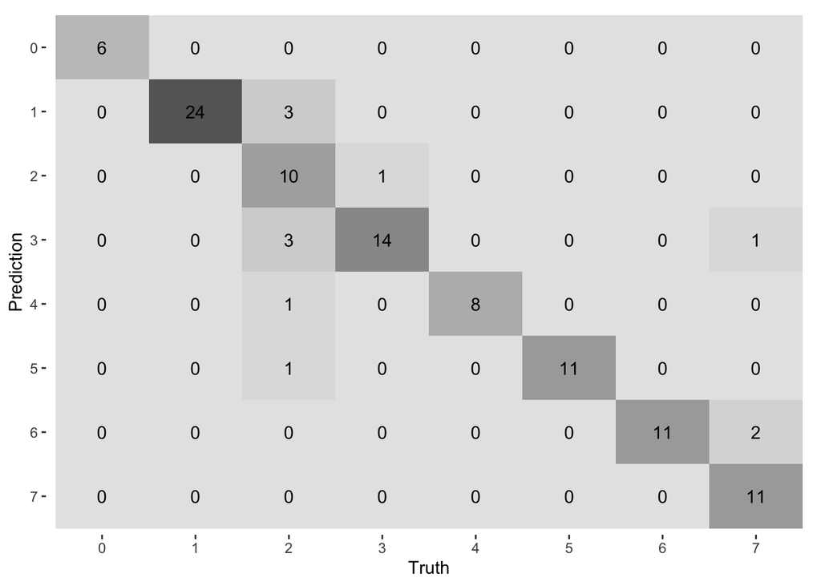

```r
log_fit_res <- fit(log_workflow, student_train)
augment(log_fit_res, student_train ) %>%
  conf_mat(truth = GRADE, estimate = .pred_class) %>%
  autoplot(type = "heatmap")
```

### Regularized Regression - Elastic Net

Similar step will be done here, we first need to set up the Elastic Net model:

```r
elastic_net <- multinom_reg(mixture = tune(),
                        penalty = tune())%>%
  set_engine('glmnet') %>%
  set_mode("classification")

elastic_workflow <- workflow() %>%
  add_model(elastic_net) %>%
  add_recipe(student_recipe)
```

```r
elastic_fit <- tune_grid(object = elastic_workflow ,
                         resamples = student_folds, elastic_grid )
collect_metrics(elastic_fit)
```

```
## # A tibble: 20 × 8
##     penalty mixture .metric  .estimator  mean     n std_err .config
##       <dbl>   <dbl> <chr>    <chr>      <dbl> <int>   <dbl> <chr>
##  1 3.42e- 9  0.0345 accuracy multiclass 0.236     7  0.0284 Preprocessor1_Model…
##  2 3.42e- 9  0.0345 roc_auc  hand_till  0.613     7  0.0264 Preprocessor1_Model…
##  3 2.59e- 5  0.149  accuracy multiclass 0.247     7  0.0302 Preprocessor1_Model…
##  4 2.59e- 5  0.149  roc_auc  hand_till  0.611     7  0.0278 Preprocessor1_Model…
##  5 2.31e- 6  0.252  accuracy multiclass 0.258     7  0.0327 Preprocessor1_Model…
##  6 2.31e- 6  0.252  roc_auc  hand_till  0.608     7  0.0277 Preprocessor1_Model…
##  7 6.33e- 4  0.380  accuracy multiclass 0.248     7  0.0328 Preprocessor1_Model…
##  8 6.33e- 4  0.380  roc_auc  hand_till  0.615     7  0.0243 Preprocessor1_Model…
##  9 1.50e-10  0.492  accuracy multiclass 0.248     7  0.0328 Preprocessor1_Model…
## 10 1.50e-10  0.492  roc_auc  hand_till  0.607     7  0.0290 Preprocessor1_Model…
## 11 5.04e- 3  0.550  accuracy multiclass 0.241     7  0.0256 Preprocessor1_Model…
## 12 5.04e- 3  0.550  roc_auc  hand_till  0.608     7  0.0242 Preprocessor1_Model…
## 13 4.64e- 7  0.602  accuracy multiclass 0.252     7  0.0370 Preprocessor1_Model…
## 14 4.64e- 7  0.602  roc_auc  hand_till  0.605     7  0.0260 Preprocessor1_Model…
## 15 1.38e- 2  0.703  accuracy multiclass 0.196     7  0.0209 Preprocessor1_Model…
## 16 1.38e- 2  0.703  roc_auc  hand_till  0.608     7  0.0199 Preprocessor1_Model…
## 17 3.46e- 8  0.860  accuracy multiclass 0.231     7  0.0291 Preprocessor1_Model…
## 18 3.46e- 8  0.860  roc_auc  hand_till  0.609     7  0.0279 Preprocessor1_Model…
## 19 4.19e- 1  0.980  accuracy multiclass 0.133     7  0.0198 Preprocessor1_Model…
## 20 4.19e- 1  0.980  roc_auc  hand_till  0.5       7  0      Preprocessor1_Model…
```

```r
show_best(elastic_fit)
```

```
## # A tibble: 5 × 8
##         penalty mixture .metric .estimator  mean     n std_err .config
##           <dbl>   <dbl> <chr>   <chr>      <dbl> <int>   <dbl> <chr>
## 1 0.000633       0.380  roc_auc hand_till  0.615     7  0.0243 Preprocessor1_Mo…
## 2 0.00000000342  0.0345 roc_auc hand_till  0.613     7  0.0264 Preprocessor1_Mo…
## 3 0.0000259      0.149  roc_auc hand_till  0.611     7  0.0278 Preprocessor1_Mo…
## 4 0.0000000346   0.860  roc_auc hand_till  0.609     7  0.0279 Preprocessor1_Mo…
## 5 0.00504        0.550  roc_auc hand_till  0.608     7  0.0242 Preprocessor1_Mo…
```

As we can see from the best performed one in the elastic net model, it is 61.5%, which is slightly better than our first model.

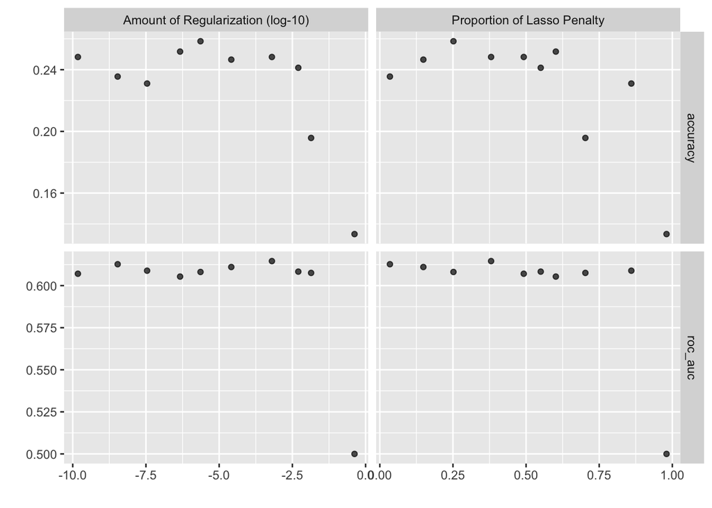

```r
autoplot(elastic_fit,matrix='roc_auc')
```

The ROC-AUC part of the graph exhibits a relatively consistent horizontal trend across all categories, with a range of 0.60 to 0.65. This consistent trend indicates a uniform performance across most of the tests conducted in this model. However, there is one notable exception with a performance around 50%. Conversely, the accuracy graph above displays more variability, depicting a wider range of performance of the model.

### Linear Discriminant Analysis (LDA)

Similar step will be done here:

```r
lda_mod <- discrim_linear() %>%
  set_engine('MASS')%>%
  set_mode('classification')

lda_workflow <- workflow()%>%
  add_model(lda_mod) %>%
  add_recipe(student_recipe)
```

```r
lda_fit <- tune_grid(object = lda_workflow, resamples = student_folds)
collect_metrics(lda_fit )
```

```
## # A tibble: 2 × 6
##   .metric  .estimator  mean     n std_err .config
##   <chr>    <chr>      <dbl> <int>   <dbl> <chr>
## 1 accuracy multiclass 0.214     7  0.0348 Preprocessor1_Model1
## 2 roc_auc  hand_till  0.567     7  0.0186 Preprocessor1_Model1
```

Select the `roc_auc`:

```r
best_lda <- collect_metrics(lda_fit )%>%
  filter(.metric == "roc_auc")
best_lda
```

```
## # A tibble: 1 × 6
##   .metric .estimator  mean     n std_err .config
##   <chr>   <chr>      <dbl> <int>   <dbl> <chr>
## 1 roc_auc hand_till  0.567     7  0.0186 Preprocessor1_Model1
```

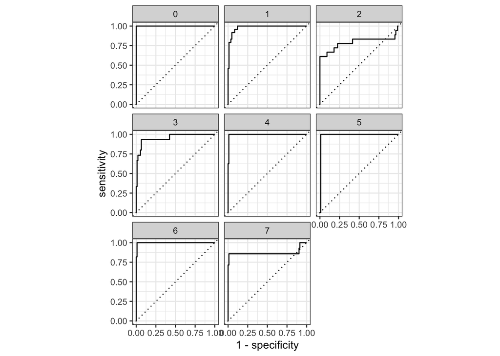

```r
lda_fit_res <- fit(lda_workflow, student_train)

augment(lda_fit_res, student_train ) %>%
 roc_curve(GRADE, .pred_0:.pred_7) %>%
 autoplot()
```

Grading scale - 0: Fail, 1: DD, 2: DC, 3: CC, 4: CB, 5: BB, 6: BA, 7: AA

From the graph, we can see that the model is best at differentiating grade 0 (fail), 5(BB), and 6(BA); the model did the worst for 2(DC). The highest prediction for this model is 56.7%, which is lower than our previous two models.

### KNN

Our fourth model is the KNN model:

```r
k_mod<- nearest_neighbor(neighbors = tune())%>%
  set_engine('kknn') %>%
  set_mode("classification")

k_workflow<- workflow()%>%
  add_model(k_mod) %>%
  add_recipe(student_recipe)
```

```r
k_fit <- tune_grid(object = k_workflow, resamples = student_folds, grid = param_grid)
collect_metrics(k_fit )
```

```
## # A tibble: 20 × 7
##    neighbors .metric  .estimator  mean     n std_err .config
##        <int> <chr>    <chr>      <dbl> <int>   <dbl> <chr>
##  1         1 accuracy multiclass 0.245     7  0.0249 Preprocessor1_Model01
##  2         1 roc_auc  hand_till  0.551     7  0.0134 Preprocessor1_Model01
##  3         2 accuracy multiclass 0.245     7  0.0249 Preprocessor1_Model02
##  4         2 roc_auc  hand_till  0.546     7  0.0157 Preprocessor1_Model02
##  5         3 accuracy multiclass 0.245     7  0.0249 Preprocessor1_Model03
##  6         3 roc_auc  hand_till  0.559     7  0.0130 Preprocessor1_Model03
##  7         4 accuracy multiclass 0.245     7  0.0249 Preprocessor1_Model04
##  8         4 roc_auc  hand_till  0.573     7  0.0169 Preprocessor1_Model04
##  9         5 accuracy multiclass 0.245     7  0.0249 Preprocessor1_Model05
## 10         5 roc_auc  hand_till  0.573     7  0.0224 Preprocessor1_Model05
## 11         6 accuracy multiclass 0.207     7  0.0279 Preprocessor1_Model06
## 12         6 roc_auc  hand_till  0.579     7  0.0227 Preprocessor1_Model06
## 13         7 accuracy multiclass 0.207     7  0.0279 Preprocessor1_Model07
## 14         7 roc_auc  hand_till  0.584     7  0.0245 Preprocessor1_Model07
## 15         8 accuracy multiclass 0.207     7  0.0279 Preprocessor1_Model08
## 16         8 roc_auc  hand_till  0.579     7  0.0276 Preprocessor1_Model08
## 17         9 accuracy multiclass 0.207     7  0.0279 Preprocessor1_Model09
## 18         9 roc_auc  hand_till  0.574     7  0.0263 Preprocessor1_Model09
## 19        10 accuracy multiclass 0.207     7  0.0279 Preprocessor1_Model10
## 20        10 roc_auc  hand_till  0.576     7  0.0295 Preprocessor1_Model10
```

select the best one:

```r
collect_metrics(k_fit)
```

```
## # A tibble: 20 × 7
##    neighbors .metric  .estimator  mean     n std_err .config
##        <int> <chr>    <chr>      <dbl> <int>   <dbl> <chr>
##  1         1 accuracy multiclass 0.245     7  0.0249 Preprocessor1_Model01
##  2         1 roc_auc  hand_till  0.551     7  0.0134 Preprocessor1_Model01
##  3         2 accuracy multiclass 0.245     7  0.0249 Preprocessor1_Model02
##  4         2 roc_auc  hand_till  0.546     7  0.0157 Preprocessor1_Model02
##  5         3 accuracy multiclass 0.245     7  0.0249 Preprocessor1_Model03
##  6         3 roc_auc  hand_till  0.559     7  0.0130 Preprocessor1_Model03
##  7         4 accuracy multiclass 0.245     7  0.0249 Preprocessor1_Model04
##  8         4 roc_auc  hand_till  0.573     7  0.0169 Preprocessor1_Model04
##  9         5 accuracy multiclass 0.245     7  0.0249 Preprocessor1_Model05
## 10         5 roc_auc  hand_till  0.573     7  0.0224 Preprocessor1_Model05
## 11         6 accuracy multiclass 0.207     7  0.0279 Preprocessor1_Model06
## 12         6 roc_auc  hand_till  0.579     7  0.0227 Preprocessor1_Model06
## 13         7 accuracy multiclass 0.207     7  0.0279 Preprocessor1_Model07
## 14         7 roc_auc  hand_till  0.584     7  0.0245 Preprocessor1_Model07
## 15         8 accuracy multiclass 0.207     7  0.0279 Preprocessor1_Model08
## 16         8 roc_auc  hand_till  0.579     7  0.0276 Preprocessor1_Model08
## 17         9 accuracy multiclass 0.207     7  0.0279 Preprocessor1_Model09
## 18         9 roc_auc  hand_till  0.574     7  0.0263 Preprocessor1_Model09
## 19        10 accuracy multiclass 0.207     7  0.0279 Preprocessor1_Model10
## 20        10 roc_auc  hand_till  0.576     7  0.0295 Preprocessor1_Model10
```

```r
best_k <- select_by_one_std_err(k_fit, metric = "roc_auc",neighbors)
best_k
```

```
## # A tibble: 1 × 9
##   neighbors .metric .estimator  mean     n std_err .config          .best .bound
##       <int> <chr>   <chr>      <dbl> <int>   <dbl> <chr>            <dbl>  <dbl>
## 1         4 roc_auc hand_till  0.573     7  0.0169 Preprocessor1_M… 0.584  0.559
```

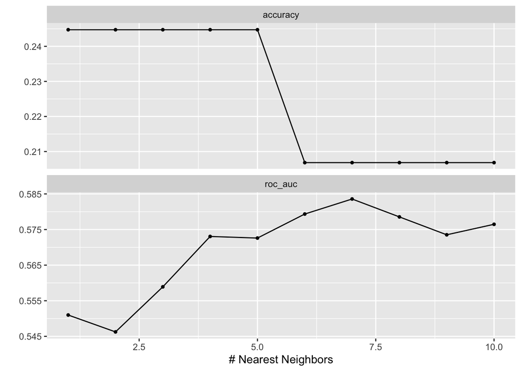

```r
autoplot(k_fit ,matrix='roc_auc')
```

### Random Forest

We first set up a grid for Random Forest first:

```r
rf_grid <- grid_regular(mtry(range = c(1, 8)),
                        trees(range = c(200, 600)),
                        min_n(range = c(10, 20)),
                        levels = 8)
```

```r
rf_class<- rand_forest(mtry = tune(),
                           trees = tune(),
                           min_n = tune()) %>%
  set_engine("ranger", importance = "impurity") %>%
  set_mode("classification")

rf_class_wf <- workflow() %>%
  add_model(rf_class) %>%
  add_recipe(student_recipe)


tune_class <- tune_grid(
  rf_class_wf,
  resamples = student_folds,
  grid = rf_grid
)
```

```r
show_best(tune_class, n = 1)
```

```
## # A tibble: 1 × 9
##    mtry trees min_n .metric .estimator  mean     n std_err .config
##   <int> <int> <int> <chr>   <chr>      <dbl> <int>   <dbl> <chr>
## 1     8   600    15 roc_auc hand_till  0.704     7  0.0213 Preprocessor1_Model3…
```

```r
best_rf <- select_best(tune_class)
```

Seems like the best prediction is with `mtry` = 8, `trees` = 600, and `min_n` = 15, wich a 70.35% prediciton. So far this is the highest among all of our models.

Let’s see what the Random Forest looks like!

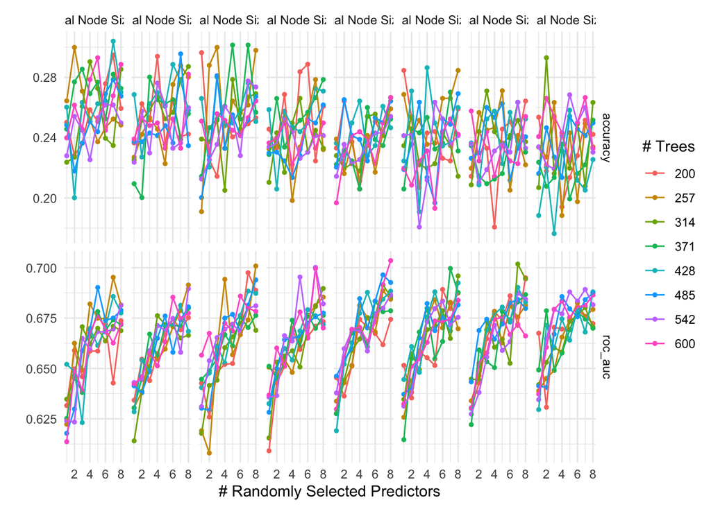

```r
autoplot(tune_class) + theme_minimal()
```

There is an increasing trend for all the Random Forest models. Increasing `mtry` increases the performance. The number of trees doesn’t really matter since all the lines have a similar shape and they are nearly on top of each other.

Overall, the Random Forest seems to be the best model, with the highest prediction of 70.4%.

### Fit the testing model

Now, let’s fit the the model to the entire training set.

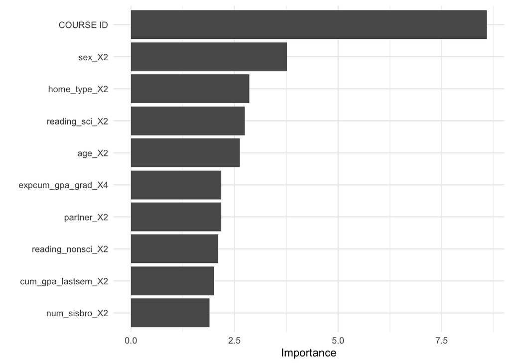

```r
final_model<- finalize_workflow(rf_class_wf, best_rf)
final_model<- fit(final_model, student_train)

final_model%>% extract_fit_parsnip()%>%
  vip(importance="impurity")+
  theme_minimal()
```

This bar graph represents how each variables plays a role in prediction. The `course_id` had the most important role since it is overwhelming long than the other variables. This make sense since different course ID represent easier or harder course, resulting a lower or higher grade. The next variable is sex, so seems like there does exist a difference between girls and boys’ performance in school. Surprisingly, `home_type` and `reading_sci` are the third significant importance group. Contrary to my initial assumption, these variables, seemingly related to external factors, play a noteworthy role in our data set. This highlights the intricate interplay between both direct and external factors influencing student grades.

Now, let’s see how the testing set will perform with this Random Forest model:

```r
augment(final_model, new_data = student_test, type = 'prob') %>%
  roc_auc(GRADE, .pred_0:.pred_7)
```

```
## # A tibble: 1 × 3
##   .metric .estimator .estimate
##   <chr>   <chr>          <dbl>
## 1 roc_auc hand_till      0.711
```

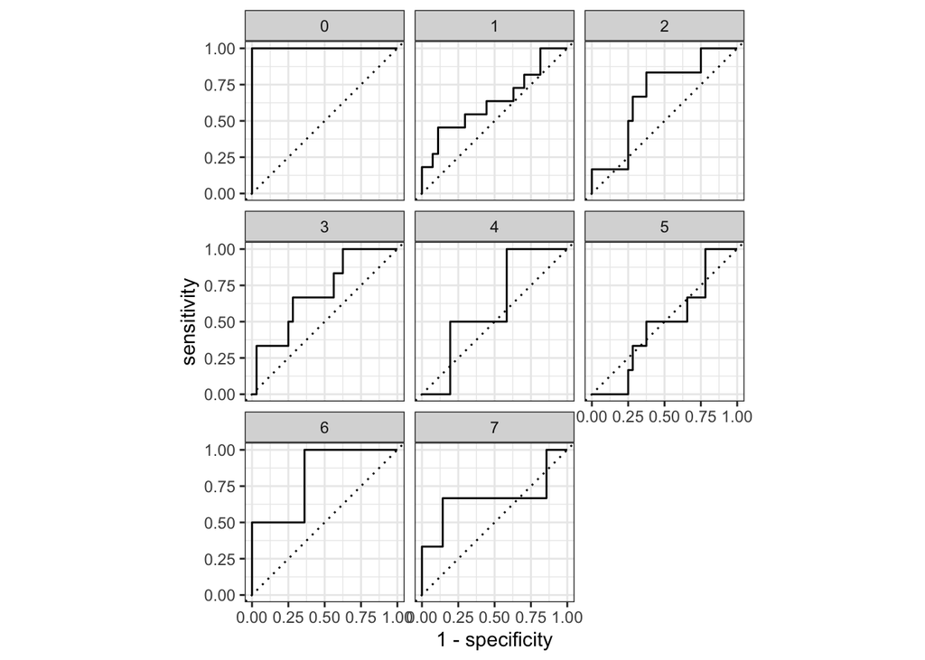

```r
augment(final_model, new_data = student_test, type = 'prob') %>%
  roc_curve(GRADE, .pred_0:.pred_7) %>%
  autoplot()
```

Grading scale - 0: Fail, 1: DD, 2: DC, 3: CC, 4: CB, 5: BB, 6: BA, 7: AA

After we fit the testing data set, the prediction is about 71%, which is just a little higher than our training set. From the graph we can see that it did the best at predicting 0 (Fail), following by 6 (BA), and did the worst around 1 (DD) and 5 (BB). Even though there is still room to get to 100%, 71% is not a worst result!

# Conclusion

Moreover, this analysis revealed that a student’s academic performance isn’t solely dictated by their performance in school. Through the various graphs explored in this project, it’s evident that external factors such as student’s parent information and family situation background also significantly influence their grades. Future studies could dig deeper into understanding the specific external factors that shape student grades, where a larger sample size and more detailed factors is needed for a comprehensive analysis.

Personally, this final project has been an enriching opportunity to apply the Machine Learning skills acquired in class, and apply it as a researcher. I found Machine Learning to be very interesting and it’s definitely something I want to study more in Graduate school. It has not only solidified my understanding of this field but also illuminated the multitude of factors contributing to grades—factors I had not previously considered.

This project isn’t just about numbers and predictions; it’s about transforming education. It’s a chance to shine a light on the unseen influences and rethink how can we improve academic success. It’s about empowering educators with the tools to create a better approaches that cater to the unique needs of each student. Ultimately, it’s about shaping a brighter future for education by comprehensively addressing the diverse factors that influence student achievement. While paying attention in class and reviewing for exams remains essential, attributing a poor grade solely to performance may not be accurate. Instead, external factors should be considered too. People shouldn’t attribute a bad grade solely to performance but should also contemplate external influences!

[figure not shown]